# ProsperLoan_part_II slides

# CreditGrade and ProsperRating_(Alpha) by LenderYield

LenderYeild shows a variation of both Grading systems, with the CreditGrade system offering a higher yield for loans from higher grades A' and 'AA' and ProsperRating_(Alpha) showing an increased loan yield for lower grades C,' 'D,' 'E,' 'NR'

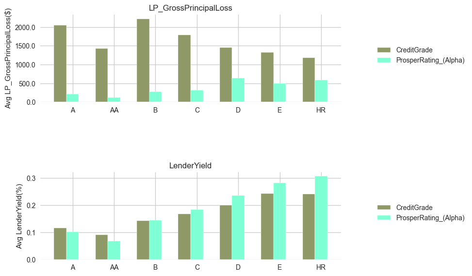

# LP_GrossPrincipalLoss and LenderYield for Loan Staus

We see how the Loan Grading systems impact the Default and charged-off LoanStatus. The `ProsperRating_(Alpha)` Shows a more even distribution across each CreditGrade for each group within each loan status, `CreditGrade`shows a higher Default and charged-off rate for the A and AA groups and a progressive decrease from the highest Grade to the least Grade.

LenderYield shows a Progressive increase for both Grading systems, from the highest grade with the least Yield and the lowest grade with the highest Yield. This explains why the difference in yield is marginal for the previous chart

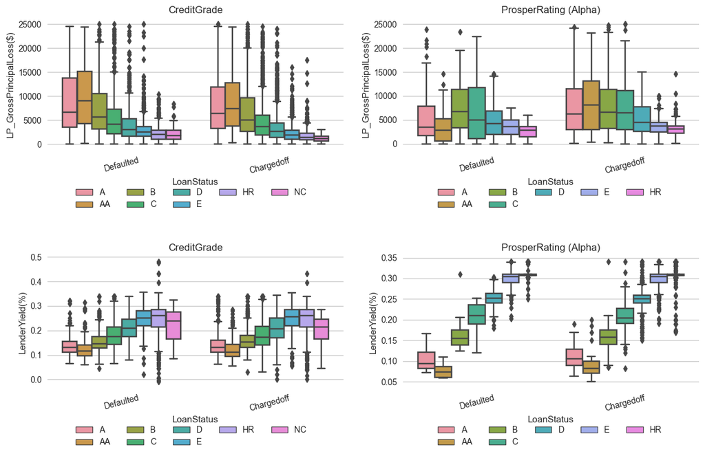